# CS 1675 Final Project: Part 5

Interpretation

Anastasia Sosnovskikh

## Load packages

Load the packages used for EDA.

```r
library(tidyverse)
```

```r
library(dplyr)
library(ggplot2)
library(caret)
library(coefplot)
library(plotROC)
```

## Load Data

Read in the data.

```r
data_url <- 'https://raw.githubusercontent.com/jyurko/CS_1675_Fall_2020/master/HW/final_project/cs_1675_final_project_data.csv'

df_raw <- readr::read_csv(data_url, col_names = TRUE)
```

Separate the variables associated with Step 1.

```r
df_step1_inputs <- df_raw %>% select(xA, xB, x01:x06, response_1)
```

Separate the variables associated with the Option B classification formulation. The `outcome_2` variable is converted to a factor with a specific ordering of the levels. This ordering is used when modeling in `caret` to make sure everyone predicts the `Fail` class as the “positive” class in the confusion matrix.

```r
df_step2_B_inputs <- df_raw %>% select(xA, xB, response_1, x07:x11, outcome_2) %>%
  mutate(outcome_2 = factor(outcome_2, levels = c('Fail', 'Pass')))
```

Separate the variables associated with the Option A classification formulation. The `outcome_2` variable is again converted to a factor with a specific ordering of the levels.

```r
df_step2_A_inputs <- df_raw %>% select(xA, xB, x01:x11, outcome_2) %>%
  mutate(outcome_2 = factor(outcome_2, levels = c('Fail', 'Pass')))
```

Change data types for the whole data frame to perform EDA.

```r
df <- df_raw %>%
  mutate(xA = as.factor(xA),
         xB = as.factor(xB),
         outcome_2 = factor(outcome_2, levels = c('Fail', 'Pass')))
```

Standardize the data.

```r
get_standardized <- function(df) {
  predict(preProcess(df, method = c('center', 'scale')), df)
}
```

## Load the best models

### Summary.

**Regression**

- eXtreme Gradient Boosting (tuned)

**Option A**

- **ROC**: Random Forest (tuned)
- **Accuracy:** eXtreme Gradient Boosting (tuned)

**Option B**

- **ROC:** eXtreme Gradient Boosting (tuned)
- **Accuracy:** eXtreme Gradient Boosting (tuned)

### Regression

Describe.

**eXtreme Gradient Boosting**: the final values used for the model were `nrounds` = `100`, `max_depth` = `6`, `eta` = `0.1`, `gamma` = `0`, `colsample_bytree` = `0.8`, `min_child_weight` = `1`, and `subsample` = `1`.

Load the model.

```r
mod_reg <- readr::read_rds('mod_reg_best.rds')
mod_reg
```

```
## eXtreme Gradient Boosting
##
## 2013 samples
##    8 predictor
##
## No pre-processing
## Resampling: Cross-Validated (5 fold, repeated 3 times)
## Summary of sample sizes: 1609, 1611, 1611, 1611, 1610, 1609, ...
## Resampling results across tuning parameters:
##
##   eta  max_depth  nrounds  RMSE      Rsquared   MAE
##   0.1  1           10      4.697862  0.3370127  3.305359
##   0.1  1           20      4.420151  0.4115679  3.101736
##   0.1  1           30      4.247485  0.4407508  2.985364
##   0.1  1           40      4.143691  0.4557131  2.914384
##   0.1  1           50      4.080413  0.4613757  2.872724
##   0.1  1           60      4.037882  0.4659700  2.842905
##   0.1  1           70      4.010833  0.4691825  2.815746
##   0.1  1           80      3.987321  0.4724860  2.791900
##   0.1  1           90      3.975185  0.4729160  2.775641
##   0.1  1          100      3.962056  0.4744065  2.761141
##   0.1  2           10      4.203903  0.5525229  2.965109
##   0.1  2           20      3.729420  0.6003188  2.666204
##   0.1  2           30      3.545712  0.6180350  2.534915
##   0.1  2           40      3.430135  0.6339986  2.439598
##   0.1  2           50      3.330039  0.6517981  2.360107
##   0.1  2           60      3.247483  0.6660912  2.299776
##   0.1  2           70      3.198135  0.6740496  2.262021
##   0.1  2           80      3.162872  0.6793704  2.231916
##   0.1  2           90      3.131120  0.6842725  2.207733
##   0.1  2          100      3.103210  0.6887199  2.188076
##   0.1  3           10      3.898181  0.6424800  2.752403
##   0.1  3           20      3.302504  0.6968780  2.369181
##   0.1  3           30      3.065976  0.7233214  2.200831
##   0.1  3           40      2.898586  0.7449871  2.080142
##   0.1  3           50      2.820435  0.7535468  2.014859
##   0.1  3           60      2.782614  0.7571317  1.980082
##   0.1  3           70      2.754340  0.7604028  1.959187
##   0.1  3           80      2.728680  0.7632602  1.937761
##   0.1  3           90      2.700454  0.7668723  1.918020
```

[output cut: 447 more lines]

```
##   0.8  6           70      2.970341  0.6989449  2.142796
##   0.8  6           80      2.972372  0.6986148  2.144837
##   0.8  6           90      2.972168  0.6986384  2.144558
##   0.8  6          100      2.973004  0.6984842  2.144826
##
## Tuning parameter 'gamma' was held constant at a value of 0
## Tuning
##
## Tuning parameter 'min_child_weight' was held constant at a value of 1
##
## Tuning parameter 'subsample' was held constant at a value of 1
## RMSE was used to select the optimal model using the smallest value.
## The final values used for the model were nrounds = 100, max_depth = 6, eta
##  = 0.1, gamma = 0, colsample_bytree = 0.8, min_child_weight = 1 and subsample
##  = 1.
```

### Classification

#### Option B

##### ROC

Describe.

**eXtreme Gradient Boosting**: the final values used for the model were `nrounds` = `20`, `max_depth` = `5`, `eta` = `0.2`, `gamma` = `0`, `colsample_bytree` = `0.8`, `min_child_weight` = `1`, and `subsample` = `1.`

Load the model.

```r
mod_class_optionB_ROC <- readr::read_rds('mod_class_optionB_ROC_best.rds')
mod_class_optionB_ROC
```

```
## eXtreme Gradient Boosting
##
## 2013 samples
##    8 predictor
##    2 classes: 'Fail', 'Pass'
##
## No pre-processing
## Resampling: Cross-Validated (5 fold, repeated 3 times)
## Summary of sample sizes: 1611, 1610, 1610, 1611, 1610, 1610, ...
## Resampling results across tuning parameters:
##
##   eta  max_depth  nrounds  ROC        Sens       Spec
##   0.1  1          10       0.6647521  0.4148900  0.8554061
##   0.1  1          20       0.7294660  0.4663283  0.8323814
##   0.1  1          30       0.7505047  0.5150592  0.8090315
##   0.1  1          40       0.7599350  0.5461929  0.7944368
##   0.1  1          50       0.7644764  0.5573604  0.7924935
##   0.1  2          10       0.7413380  0.5035533  0.8151898
##   0.1  2          20       0.7711782  0.5786802  0.7899061
##   0.1  2          30       0.7819545  0.6223350  0.7775815
##   0.1  2          40       0.7873077  0.6456853  0.7756319
##   0.1  2          50       0.7915583  0.6602369  0.7717405
##   0.1  3          10       0.7642604  0.5786802  0.7915052
##   0.1  3          20       0.7841411  0.6426396  0.7753035
##   0.1  3          30       0.7911985  0.6629442  0.7710837
##   0.1  3          40       0.7954003  0.6842640  0.7616671
##   0.1  3          50       0.7973252  0.6886633  0.7629679
##   0.1  4          10       0.7795341  0.6294416  0.7727113
##   0.1  4          20       0.7922606  0.6795262  0.7580961
##   0.1  4          30       0.7999137  0.6920474  0.7590796
##   0.1  4          40       0.8015071  0.6998308  0.7584308
##   0.1  4          50       0.8024760  0.7008460  0.7590891
##   0.1  5          10       0.7877419  0.6737733  0.7707412
##   0.1  5          20       0.7971344  0.6971235  0.7577851
##   0.1  5          30       0.8014214  0.7103215  0.7610214
##   0.1  5          40       0.8031710  0.7157360  0.7561733
##   0.1  5          50       0.8037052  0.7201354  0.7522709
##   0.1  6          10       0.7896462  0.6906937  0.7480275
##   0.1  6          20       0.7995973  0.7126904  0.7516000
##   0.1  6          30       0.8019630  0.7194585  0.7490078
```

[output cut: 208 more lines]

```
##   0.8  6          20       0.7607723  0.6903553  0.7188681
##   0.8  6          30       0.7585056  0.6859560  0.7166012
##   0.8  6          40       0.7572890  0.6849408  0.7230847
##   0.8  6          50       0.7572504  0.6849408  0.7221107
##
## Tuning parameter 'gamma' was held constant at a value of 0
## Tuning
##
## Tuning parameter 'min_child_weight' was held constant at a value of 1
##
## Tuning parameter 'subsample' was held constant at a value of 1
## ROC was used to select the optimal model using the largest value.
## The final values used for the model were nrounds = 20, max_depth = 5, eta
##  = 0.2, gamma = 0, colsample_bytree = 0.8, min_child_weight = 1 and subsample
##  = 1.
```

##### Accuracy

Describe.

**eXtreme Gradient Boosting**: the final values used for the model were `nrounds` = `40`, `max_depth` = `4`, `eta` = `0.2`, `gamma` = `0`, `colsample_bytree` = `0.8`, `min_child_weight` = `1`, and `subsample` = `1.`

Load the model.

```r
mod_class_optionB_Accuracy <- readr::read_rds('mod_class_optionB_Accuracy_best.rds')
mod_class_optionB_Accuracy
```

```
## eXtreme Gradient Boosting
##
## 2013 samples
##    8 predictor
##    2 classes: 'Fail', 'Pass'
##
## No pre-processing
## Resampling: Cross-Validated (5 fold, repeated 3 times)
## Summary of sample sizes: 1611, 1610, 1610, 1611, 1610, 1610, ...
## Resampling results across tuning parameters:
##
##   eta  max_depth  nrounds  Accuracy   Kappa
##   0.1  1          10       0.6398397  0.2727089
##   0.1  1          20       0.6532544  0.3009007
##   0.1  1          30       0.6651766  0.3260141
##   0.1  1          40       0.6729566  0.3423272
##   0.1  1          50       0.6774272  0.3514955
##   0.1  2          10       0.6626960  0.3207453
##   0.1  2          20       0.6865384  0.3701103
##   0.1  2          30       0.7016041  0.4011151
##   0.1  2          40       0.7120386  0.4223531
##   0.1  2          50       0.7171714  0.4328746
##   0.1  3          10       0.6873704  0.3717398
##   0.1  3          20       0.7103815  0.4189826
##   0.1  3          30       0.7181668  0.4349119
##   0.1  3          40       0.7237913  0.4465494
##   0.1  3          50       0.7266068  0.4522179
##   0.1  4          10       0.7025941  0.4032297
##   0.1  4          20       0.7196474  0.4382306
##   0.1  4          30       0.7262731  0.4516488
##   0.1  4          40       0.7297507  0.4587177
##   0.1  4          50       0.7305816  0.4603938
##   0.1  5          10       0.7232983  0.4453105
##   0.1  5          20       0.7280994  0.4553638
##   0.1  5          30       0.7362089  0.4717185
##   0.1  5          40       0.7363793  0.4721941
##   0.1  5          50       0.7365427  0.4726049
##   0.1  6          10       0.7199849  0.4391414
##   0.1  6          20       0.7325671  0.4645455
##   0.1  6          30       0.7345535  0.4686316
```

[output cut: 208 more lines]

```
##   0.8  6          20       0.7049146  0.4093372
##   0.8  6          30       0.7016057  0.4026982
##   0.8  6          40       0.7044159  0.4082351
##   0.8  6          50       0.7039180  0.4072619
##
## Tuning parameter 'gamma' was held constant at a value of 0
## Tuning
##
## Tuning parameter 'min_child_weight' was held constant at a value of 1
##
## Tuning parameter 'subsample' was held constant at a value of 1
## Accuracy was used to select the optimal model using the largest value.
## The final values used for the model were nrounds = 40, max_depth = 4, eta
##  = 0.2, gamma = 0, colsample_bytree = 0.8, min_child_weight = 1 and subsample
##  = 1.
```

#### Option A

##### ROC

Describe.

**Random Forest**: the final value used for the model was `mtry` = `4`.

Load the model.

```r
mod_class_optionA_ROC <- readr::read_rds('mod_class_optionA_ROC_best.rds')
mod_class_optionA_ROC
```

```
## Random Forest
##
## 2013 samples
##   13 predictor
##    2 classes: 'Fail', 'Pass'
##
## No pre-processing
## Resampling: Cross-Validated (5 fold, repeated 3 times)
## Summary of sample sizes: 1611, 1610, 1610, 1611, 1610, 1610, ...
## Resampling results across tuning parameters:
##
##   mtry  ROC        Sens       Spec
##    1    0.7454519  0.4879865  0.8229489
##    2    0.7924803  0.7143824  0.7263225
##    3    0.8003992  0.7482234  0.7220980
##    4    0.8031029  0.7566836  0.7152940
##    5    0.8026913  0.7617597  0.7152972
##    6    0.8023923  0.7583756  0.7123830
##    7    0.8006651  0.7661591  0.7110806
##    8    0.7993437  0.7543147  0.7110822
##    9    0.7983695  0.7580372  0.7123735
##   10    0.7970561  0.7556684  0.7084900
##
## ROC was used to select the optimal model using the largest value.
## The final value used for the model was mtry = 4.
```

##### Accuracy

Describe.

**eXtreme Gradient Boosting**: the final values used for the model were `nrounds` = `50`, `max_depth` = `4`, `eta` = `0.1`, `gamma` = `0`, `colsample_bytree` = `0.8`, `min_child_weight` = `1`, and `subsample` = `1.`

Load the model.

```r
mod_class_optionA_Accuracy <- readr::read_rds('mod_class_optionA_Accuracy_best.rds')
mod_class_optionA_Accuracy
```

```
## eXtreme Gradient Boosting
##
## 2013 samples
##   13 predictor
##    2 classes: 'Fail', 'Pass'
##
## No pre-processing
## Resampling: Cross-Validated (5 fold, repeated 3 times)
## Summary of sample sizes: 1611, 1610, 1610, 1611, 1610, 1610, ...
## Resampling results across tuning parameters:
##
##   eta  max_depth  nrounds  Accuracy   Kappa
##   0.1  1          10       0.6188141  0.2310605
##   0.1  1          20       0.6476221  0.2902525
##   0.1  1          30       0.6621989  0.3199662
##   0.1  1          40       0.6729673  0.3420509
##   0.1  1          50       0.6825632  0.3617927
##   0.1  2          10       0.6582209  0.3125661
##   0.1  2          20       0.6858750  0.3686934
##   0.1  2          30       0.6974589  0.3925685
##   0.1  2          40       0.7072347  0.4124307
##   0.1  2          50       0.7126975  0.4237355
##   0.1  3          10       0.6871992  0.3720727
##   0.1  3          20       0.7095515  0.4173165
##   0.1  3          30       0.7171718  0.4330096
##   0.1  3          40       0.7232975  0.4454747
##   0.1  3          50       0.7272644  0.4536715
##   0.1  4          10       0.7016024  0.4019063
##   0.1  4          20       0.7247876  0.4484904
##   0.1  4          30       0.7322379  0.4636067
##   0.1  4          40       0.7365427  0.4723097
##   0.1  4          50       0.7393541  0.4779767
##   0.1  5          10       0.7107087  0.4203016
##   0.1  5          20       0.7256122  0.4503649
##   0.1  5          30       0.7350493  0.4694119
##   0.1  5          40       0.7357155  0.4707580
##   0.1  5          50       0.7337288  0.4668348
##   0.1  6          10       0.7097177  0.4186230
##   0.1  6          20       0.7206466  0.4406727
##   0.1  6          30       0.7270998  0.4536450
```

[output cut: 208 more lines]

```
##   0.8  6          20       0.6933175  0.3860704
##   0.8  6          30       0.6954775  0.3903878
##   0.8  6          40       0.6994498  0.3983173
##   0.8  6          50       0.6931607  0.3856625
##
## Tuning parameter 'gamma' was held constant at a value of 0
## Tuning
##
## Tuning parameter 'min_child_weight' was held constant at a value of 1
##
## Tuning parameter 'subsample' was held constant at a value of 1
## Accuracy was used to select the optimal model using the largest value.
## The final values used for the model were nrounds = 50, max_depth = 4, eta
##  = 0.1, gamma = 0, colsample_bytree = 0.8, min_child_weight = 1 and subsample
##  = 1.
```

## Compare the performance

### ROC

Get the data.

```r
best_models_class_ROC <- list(all_optionA = mod_class_optionA_ROC,
                              with_reg_OptionB = mod_class_optionB_ROC)
```

Plot the metric.

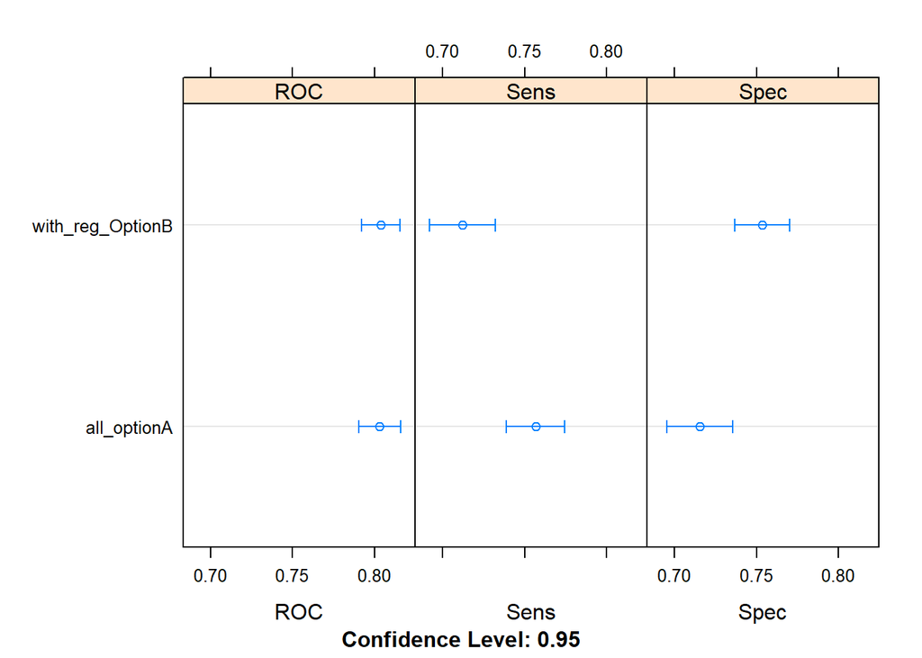

```r
best_models_class_ROC %>% resamples() %>% dotplot()
```

Plot the ROC.

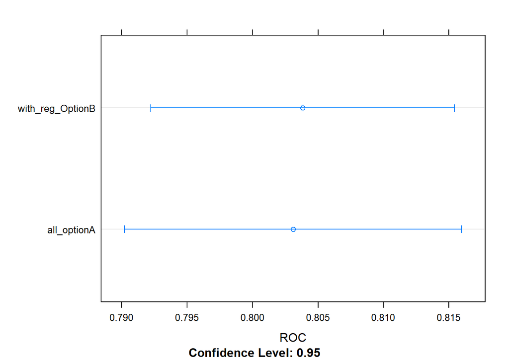

```r
best_models_class_ROC %>% resamples() %>% dotplot(metric = 'ROC')
```

### Plot ROC

Assemble the ROC curves for comparison.

```r
cv_pred_results <- mod_class_optionA_ROC$pred %>% tbl_df() %>%
              filter(mtry == mod_class_optionA_ROC$bestTune$mtry) %>%
              select(pred, obs, Fail, Pass, rowIndex, Resample) %>%
              mutate(model_name = 'all_optionA (RF_tuned)') %>%
    bind_rows( mod_class_optionB_ROC$pred %>% tbl_df() %>%
              filter(nrounds == mod_class_optionB_ROC$bestTune$nrounds,
                     max_depth == mod_class_optionB_ROC$bestTune$max_depth,
                     eta == mod_class_optionB_ROC$bestTune$eta,
                     gamma == mod_class_optionB_ROC$bestTune$gamma,
                     colsample_bytree == mod_class_optionB_ROC$bestTune$colsample_bytree,
                     min_child_weight == mod_class_optionB_ROC$bestTune$min_child_weight ,
                     subsample == mod_class_optionB_ROC$bestTune$subsample) %>%
              select(pred, obs, Fail, Pass, rowIndex, Resample) %>%
              mutate(model_name = 'with_reg_optionB (XGB_tuned)'))
```

Plot the ROC.

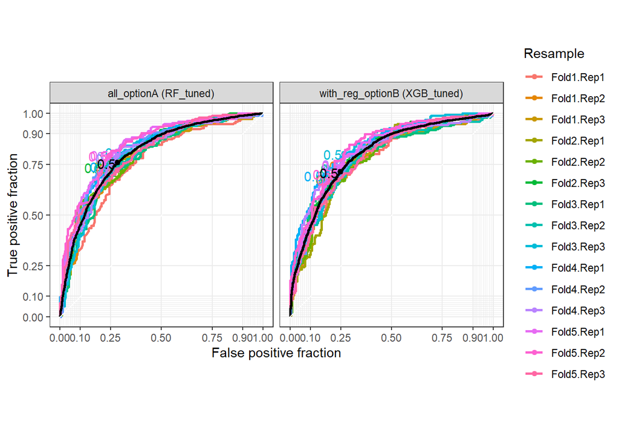

```r
cv_pred_results %>%
  ggplot(mapping = aes(m = Fail,
                       d = ifelse(obs == 'Fail',
                                  1,
                                  0))) +
  geom_roc(cutoffs.at = 0.5,
           mapping = aes(color = Resample)) +
  geom_roc(cutoffs.at = 0.5) +
  coord_equal() +
  facet_wrap(~ model_name) +
  style_roc()
```

Compare the cross-validation averaged ROC curves across the best models directly.

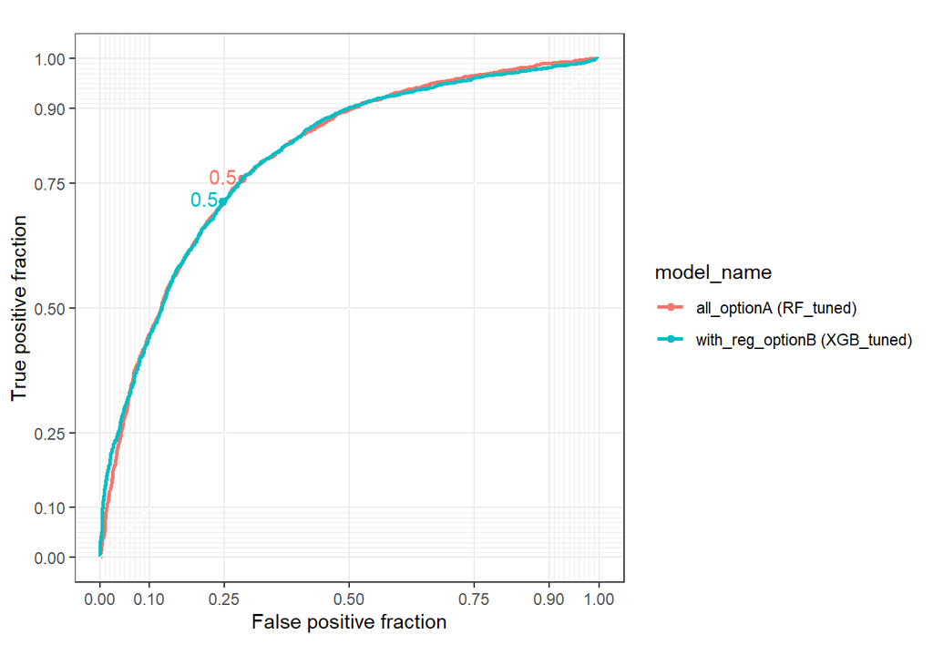

```r
cv_pred_results %>%
  ggplot(mapping = aes(m = Fail,
                       d = ifelse(obs == 'Fail',
                                  1,
                                  0),
                       color = model_name)) +
  geom_roc(cutoffs.at = 0.5) +
  coord_equal() +
  style_roc()
```

*Thus, my choice for the best ROC is a **model for option B**.*

### Accuracy

Get a list of models.

```r
best_models_class_Accuracy <- list(all_optionA = mod_class_optionA_Accuracy,
                                   with_reg_OptionB = mod_class_optionB_Accuracy)
```

Print out confusion matrix.

```r
mod_class_optionA_Accuracy %>%  confusionMatrix.train()
```

```
## Cross-Validated (5 fold, repeated 3 times) Confusion Matrix
##
## (entries are percentual average cell counts across resamples)
##
##           Reference
## Prediction Fail Pass
##       Fail 34.8 11.9
##       Pass 14.1 39.1
##
##  Accuracy (average) : 0.7394
```

```r
mod_class_optionB_Accuracy %>%  confusionMatrix.train()
```

```
## Cross-Validated (5 fold, repeated 3 times) Confusion Matrix
##
## (entries are percentual average cell counts across resamples)
##
##           Reference
## Prediction Fail Pass
##       Fail 35.1 12.4
##       Pass 13.9 38.6
##
##  Accuracy (average) : 0.7369
```

Plot the metric.

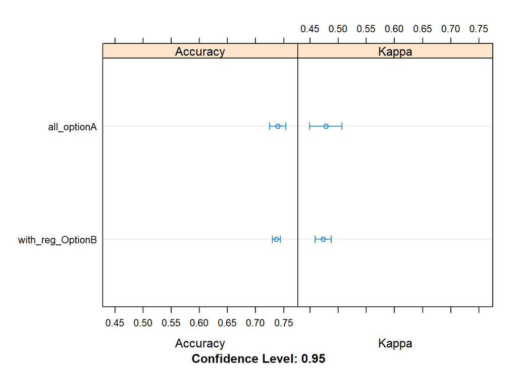

```r
best_models_class_Accuracy %>% resamples() %>% dotplot()
```

Plot Accuracy.

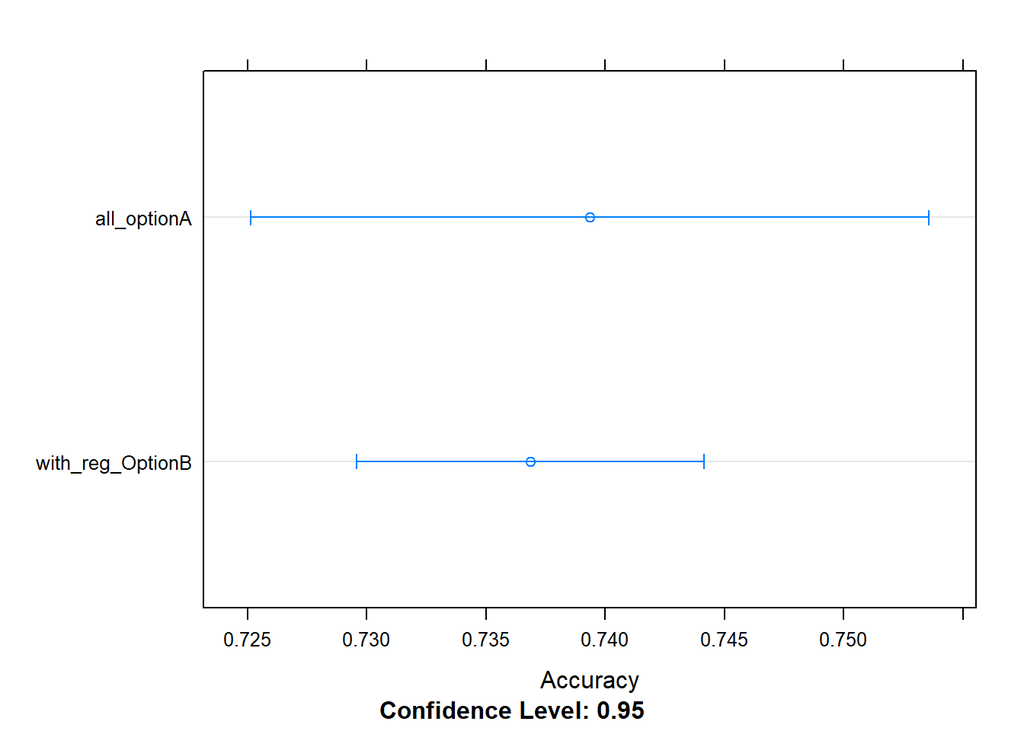

```r
best_models_class_Accuracy %>% resamples() %>% dotplot(metric = 'Accuracy')
```

*Thus, my choice for the accuracy is a **model for option B**.*

## Variable importance rankings

Functions to get the most important variables.

```r
get_4_imp_vars <- function(model) {
  top_inputs <- (varImp(model))$importance %>%
    tibble::rownames_to_column('var_name') %>%
    arrange(desc(Overall)) %>%
    slice(1:4) %>%
    pull(var_name)
}
```

```r
imp_var_threshold = 60

get_list_imp_vars <- function(model) {
  (varImp(model))$importance %>%
    tibble::rownames_to_column('var_name') %>%
    filter(Overall > imp_var_threshold) %>%
    pull(var_name)
}
```

### Plot

#### Regression

Show variable importance graph for **Regression - RMSE**.

```
## [15:20:00] WARNING: amalgamation/../src/objective/regression_obj.cu:174: reg:linear is now deprecated in favor of reg:squarederror.
```

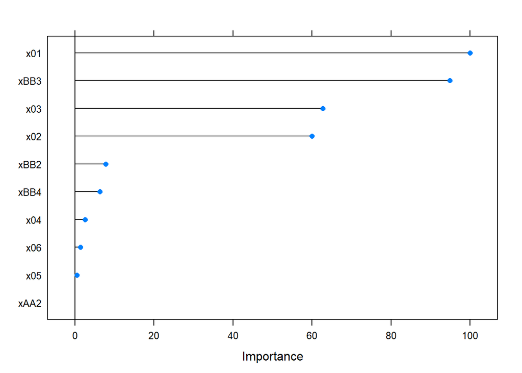

```r
mod_reg %>%  varImp() %>%  plot()
```

Get the most important variables with a threshold of `60`.

```r
reg_imp_vars <- mod_reg %>% get_list_imp_vars()
```

```
## [15:20:01] WARNING: amalgamation/../src/objective/regression_obj.cu:174: reg:linear is now deprecated in favor of reg:squarederror.
```

```r
reg_imp_vars
```

```
## [1] "x01"  "xBB3" "x03"  "x02"
```

*The most important variables for the best model for regression are `x01, xBB3, x03, x02`. This is consistent with my visualizations from the EDA part of the project because I found `x01:x03` to be the most important variables for `response_1`. I have also found that `xA` does not have any impact on the `response_1` and as we can see no levels of `xA` appear to be significant. On the other hand, the levels of `xB` are important for `response_1` which is supported by both the graph above and the EDA.*

#### Classification

Show variable importance graph for **Option B - ROC**.

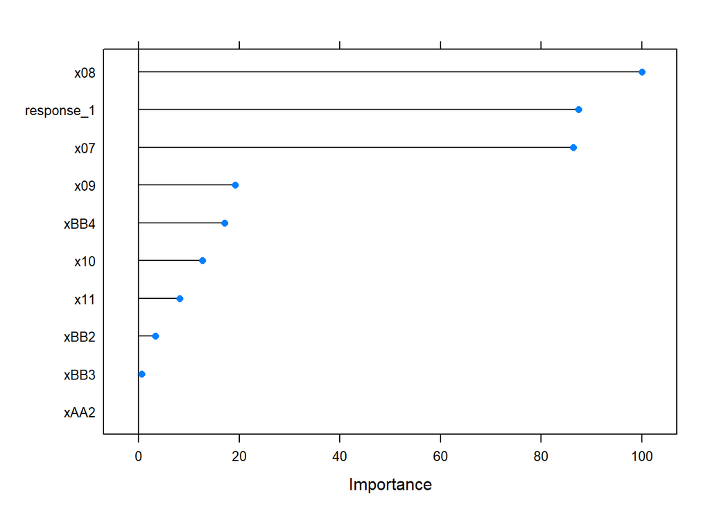

```r
mod_class_optionB_ROC %>%  varImp() %>%  plot()
```

Get the most important variables with a threshold of `60`.

```r
class_optionB_ROC_imp_vars <- mod_class_optionB_ROC %>% get_list_imp_vars()
class_optionB_ROC_imp_vars
```

```
## [1] "x08"        "response_1" "x07"
```

*The most important variables for the best model for classification option B - ROC are `x08, response_1, x07`. This is consistent with my visualizations from the EDA part of the project because I found all of them to be important variables for `outcome_1` as well as `x09`. I have also found that `xA` does not have any impact on the `outcome_2` and as we can see no levels of `xA` appear to be significant. On the other hand, the levels of `xB` are important for `outcome_2` which is supported by both the graph above and the EDA.*

Show variable importance graph for **Option B - Accuracy**.

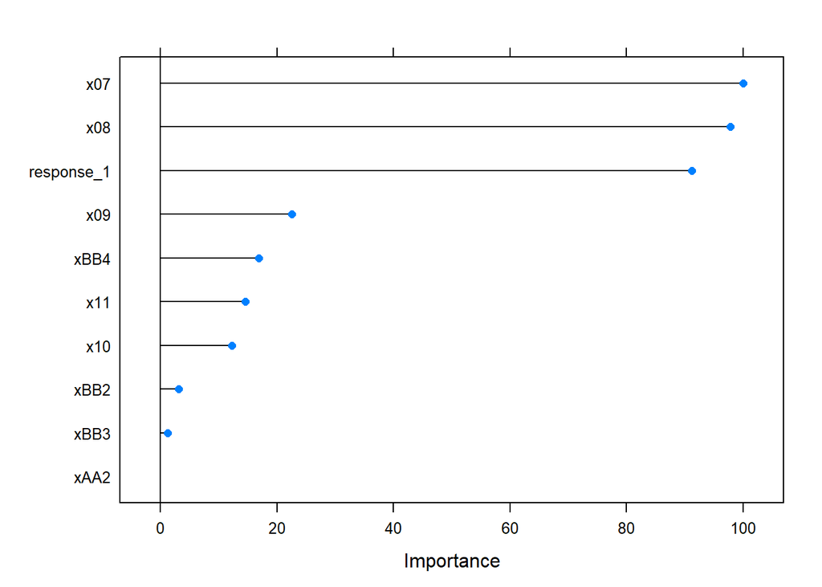

```r
mod_class_optionB_Accuracy %>%  varImp() %>%  plot()
```

Get the most important variables with a threshold of `60`.

```r
class_optionB_Accuracy_imp_vars <- mod_class_optionB_Accuracy %>% get_list_imp_vars()
class_optionB_Accuracy_imp_vars
```

```
## [1] "x07"        "x08"        "response_1"
```

*The most important variables for the best model for classification option B - Accuracy are `x07, x08, response_1`. This is consistent with my visualizations from the EDA part of the project because I found all of them to be important variables for `outcome_1` as well as `x09`. I have also found that `xA` does not have any impact on the `outcome_2` and as we can see no levels of `xA` appear to be significant. On the other hand, the levels of `xB` are important for `Outcome_2` which is supported by both the graph above and the EDA.*

*It is interesting to note that the same variables were important overall for option B for both accuracy and ROC but their order slightly changes.*

Show variable importance graph for **Option A - ROC**.

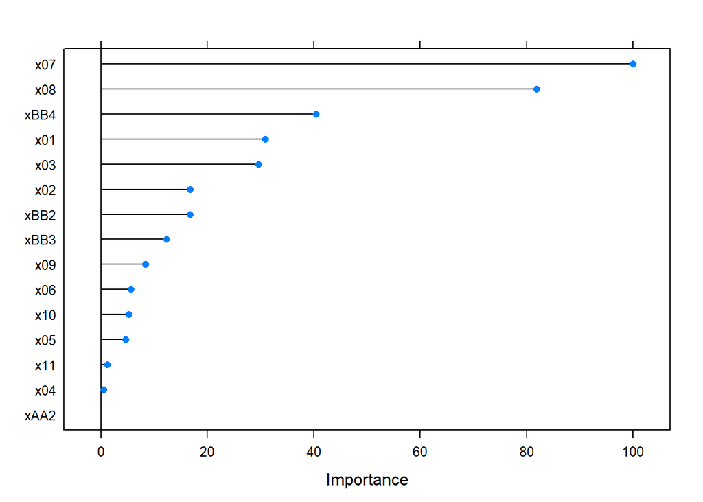

```r
mod_class_optionA_ROC %>%  varImp() %>%  plot()
```

Get the most important variables with a threshold of `60`.

```r
# has Fail and Pass instead of Overall for some reason
class_optionA_ROC_imp_vars <-  (varImp(mod_class_optionA_ROC))$importance %>%
    tibble::rownames_to_column('var_name') %>%
    filter(Fail > imp_var_threshold) %>%
    pull(var_name)

class_optionA_ROC_imp_vars
```

```
## [1] "x07" "x08"
```

*The most important variables for the best model for classification option A - ROC are `x07, x08`. The best continuous inputs are `x07` and `x08` again, but the next best is `xBB4` which was less important for option B models. Also, `x09` is not as important for option A as for option B.*

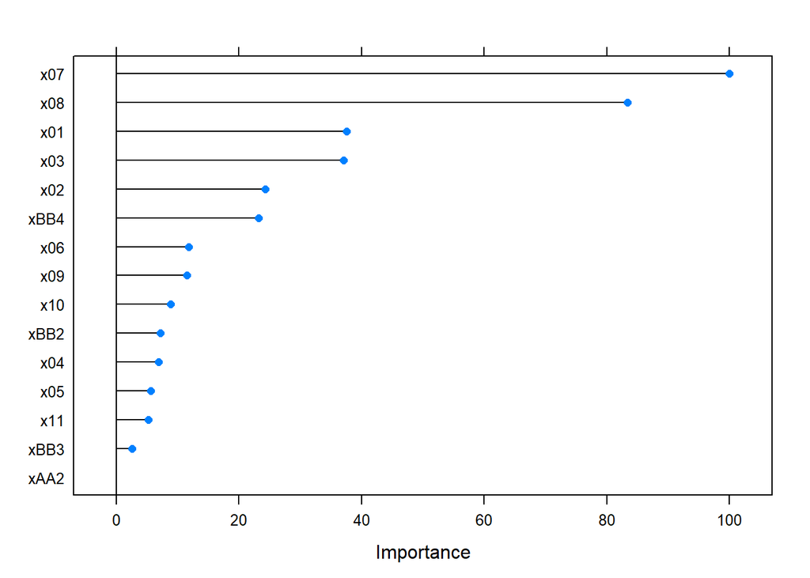

```r
mod_class_optionA_Accuracy %>%  varImp() %>%  plot()
```

Get the most important variables with a threshold of `60`.

```r
class_optionA_Accuracy_imp_vars <- mod_class_optionA_Accuracy %>% get_list_imp_vars()
class_optionA_Accuracy_imp_vars
```

```
## [1] "x07" "x08"
```

*The most important variables for the best model for classification option A - Accuracy are `x07, x08`. The best continuous inputs are `x07` and `x08` again, but this time other continuous variables `x01:x03` are next most important which are important for `response_1`. The next important variable is `xBB4` again as for ROC.*

*For the models that use `response_`, it was in the top 3 most important variables.*

## Discussion - what model is ultimately the best

*For both of the metrics (ROC and Accuracy), the best models were really close to each other in their performance. There is no definite way I am aware of to rate the complexity of the models in order to use the one standard rule to pick the best model; thus, when making my final choice for each of the metrics, I was choosing the best model based on the performance and uncertainty intervals. Mainly, I wanted the uncertainty interval to be as small to avoid the chances of getting a lower performance. Thus, the best models for both maximizing ROC and Accuracy were associated with **option B**. They were both tuned Gradient Boosted Trees.*

- **ROC**

**eXtreme Gradient Boosting**: the final values used for the model were `nrounds` = `20`, `max_depth` = `5`, `eta` = `0.2`, `gamma` = `0`, `colsample_bytree` = `0.8`, `min_child_weight` = `1`, and `subsample` = `1.`

- **Accuracy**

**eXtreme Gradient Boosting**: the final values used for the model were `nrounds` = `40`, `max_depth` = `4`, `eta` = `0.2`, `gamma` = `0`, `colsample_bytree` = `0.8`, `min_child_weight` = `1`, and `subsample` = `1.`

*Additionally, we have to remember that even though the models for option B were the best in performance, we have to also consider the models to estimate the `response_1`. Thus, in practice, it could be the case that option B models would perform worse because it requires more steps and you need to use different models to optimize for the inputs. However, for this assignment, I am choosing the best one more based on performance.*

*Now, to choose the best one from these two to use for optimization, we need to focus on the metric more. These model differ in 2 tuning parameters only: `nrounds` and `max_depth`. I think that I will go with ROC as the metric of choice because accuracy depends on the threshold chosen by the algorithm whereas AUC ROC takes into account all possible thresholds. Thus, I think that AUC ROC provides a broader view of the performance of the model compared to the accuracy. Although they do measure different things.*

*It is worth noting that tree-based models seemed to be superior for this problem for all the options with Gradient Boosted Tree being the best one. Although tuning the model matters a lot since the default Gradient Boosted Tree was not the best in any of the part of this final project. Other models that were close to it were Random Forest both default and tuned as well as tuned Neural Network. Generalize Additive model seem to perform good as well. However, LM and GLM, Elastic Net, and Partial Least Squares (PLS) seemed to be the worst ones across all the trials. PLS did not work well because it performs well with correlated inputs but the inputs for this problem were uncorrelated as we found out in the EDA part of the project and then proved by training the PLS models.*

## Visualize the probability of failure for the best model

*The best model was chosen to be Option B - ROC.*

### Making predictions

Create a prediction grid.

```r
df_step2_B_inputs %>% select(-outcome_2) %>% dim()
```

```
## [1] 2013    8
```

Define a function to help create the grid of input values.

Specify evenly spaced values between the min and max for the top inputs. All other inputs will be fixed at their median values.

```r
make_input_grid <- function(var_name, top_input_names, all_data)
{
  xvar <- all_data %>% select(all_of(var_name)) %>% pull()

  if (var_name %in% top_input_names[1:2]){
    # use 25 unique values between the min/max values
    xgrid <- seq(min(xvar), max(xvar), length.out = 25)
  } else if (var_name %in% top_input_names[3:4]){
    # specify quantiles to use
    xgrid <- quantile(xvar, probs = c(0.05, 0.25, 0.5, 0.75, 0.95), na.rm = TRUE)
    xgrid <- as.vector(xgrid)
  } else {
    # set to their median values
    xgrid <- median(xvar, na.rm = TRUE)
  }

  xgrid
}
```

Create a list of features.

```r
all_input_names <- df_step2_B_inputs %>% select(-outcome_2) %>% names()
all_input_names
```

```
## [1] "xA"         "xB"         "response_1" "x07"        "x08"
## [6] "x09"        "x10"        "x11"
```

Get 4 variables to visualize.

```r
four_imp_vars <- mod_class_optionB_ROC %>%  get_4_imp_vars()
four_imp_vars
```

```
## [1] "x08"        "response_1" "x07"        "x09"
```

Create a list where 1 element in the list corresponds to an input feature.

```r
test_input_list <- purrr::map(all_input_names,
                              make_input_grid,
                              top_input_names = four_imp_vars,
                              all_data = df_step2_B_inputs)

test_input_list %>% length()
```

```
## [1] 8
```

Convert the list into a data frame for the grid.

```r
test_input_grid <- expand.grid(test_input_list,
                               KEEP.OUT.ATTRS = FALSE,
                               stringsAsFactors = FALSE) %>%
  purrr::set_names(all_input_names)

test_input_grid %>% glimpse()
```

```
## Rows: 15,625
## Columns: 8
## $ xA         <chr> "A2", "A2", "A2", "A2", "A2", "A2", "A2", "A2", "A2", "A...
## $ xB         <chr> "B2", "B2", "B2", "B2", "B2", "B2", "B2", "B2", "B2", "B...
## $ response_1 <dbl> -30.5376195, -28.0331641, -25.5287088, -23.0242535, -20....
## $ x07        <dbl> 142.3443, 142.3443, 142.3443, 142.3443, 142.3443, 142.34...
## $ x08        <dbl> 74.03725, 74.03725, 74.03725, 74.03725, 74.03725, 74.037...
## $ x09        <dbl> 134.5283, 134.5283, 134.5283, 134.5283, 134.5283, 134.52...
## $ x10        <dbl> 60.78998, 60.78998, 60.78998, 60.78998, 60.78998, 60.789...
## $ x11        <dbl> 106.6791, 106.6791, 106.6791, 106.6791, 106.6791, 106.67...
```

Make predictions on the grid for **classes**.

```r
pred_test_class_optionB_ROC <- predict(mod_class_optionB_ROC, test_input_grid)
pred_test_class_optionB_ROC %>%  head()
```

```
## [1] Fail Fail Fail Fail Fail Fail
## Levels: Fail Pass
```

Visualize Predicted Classes.

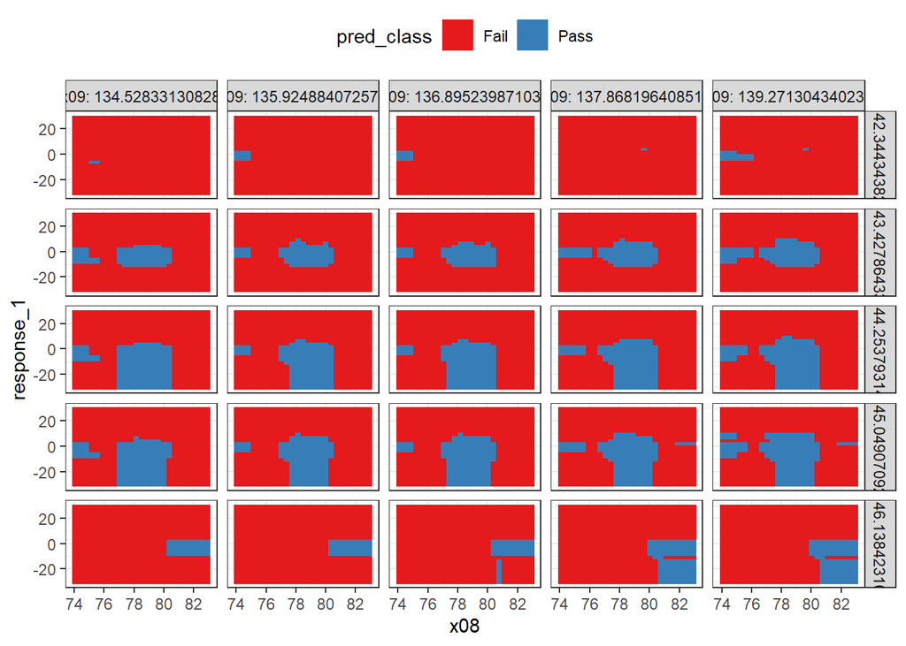

```r
test_input_grid %>%
  mutate(pred_class = pred_test_class_optionB_ROC) %>%
  ggplot(mapping = aes(x = x08, y = response_1)) +
  geom_raster(mapping = aes(fill = pred_class)) +
  facet_grid(x07 ~ x09, labeller = "label_both") +
  scale_fill_brewer(palette = "Set1") +
  theme_bw() +
  theme(legend.position = "top")
```

Make predictions on the grid for **probabilities**.

```r
pred_test_class_optionB_ROC_probs <- predict(mod_class_optionB_ROC, test_input_grid, type = 'prob')
pred_test_class_optionB_ROC_probs %>%  head()
```

```
##        Fail      Pass
## 1 0.5828373 0.4171627
## 2 0.5828373 0.4171627
## 3 0.5828373 0.4171627
## 4 0.5828373 0.4171627
## 5 0.5828373 0.4171627
## 6 0.5828373 0.4171627
```

Visualize predicted probabilities.

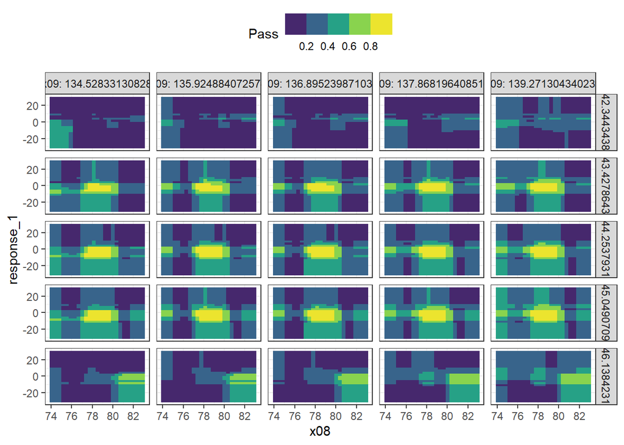

```r
test_input_grid %>%
  bind_cols(pred_test_class_optionB_ROC_probs) %>%
  ggplot(mapping = aes(x = x08, y = response_1)) +
  geom_raster(mapping = aes(fill = Pass)) +
  facet_grid(x07 ~ x09, labeller = "label_both") +
  scale_fill_viridis_b() +
  theme_bw() +
  theme(legend.position = "top")
```

#### What input settings are associated with minimizing the failure probability? Do the optimal input settings vary across discrete groups?

*Discrete groups did not end up being the most important variables, so it is likely that the trends in the probability would not change if we vary discrete groups’ input values.*